# Quantified Self Data Analyis

Peter Petto, for Coursera Reproducible Research Peer Assessment #1

September 13, 2014

This is an R Markdown file, for the first peer assessment assignment in the John Hopkins’ Coursera MOOC, Reproducible Research.

### Loading the Data

This first R code reads in the raw data, displays the first six records and also displays the final six records.

```r
rawActivity = read.csv("activity.csv", header = TRUE)
head(rawActivity)
```

```
##   steps       date interval
## 1    NA 2012-10-01        0
## 2    NA 2012-10-01        5
## 3    NA 2012-10-01       10
## 4    NA 2012-10-01       15
## 5    NA 2012-10-01       20
## 6    NA 2012-10-01       25
```

```r
tail(rawActivity)
```

```
##       steps       date interval
## 17563    NA 2012-11-30     2330
## 17564    NA 2012-11-30     2335
## 17565    NA 2012-11-30     2340
## 17566    NA 2012-11-30     2345
## 17567    NA 2012-11-30     2350
## 17568    NA 2012-11-30     2355
```

Here is the default summary information for all three raw data variables:

```
##      steps               date          interval
##  Min.   :  0.0   2012-10-01:  288   Min.   :   0
##  1st Qu.:  0.0   2012-10-02:  288   1st Qu.: 589
##  Median :  0.0   2012-10-03:  288   Median :1178
##  Mean   : 37.4   2012-10-04:  288   Mean   :1178
##  3rd Qu.: 12.0   2012-10-05:  288   3rd Qu.:1766
##  Max.   :806.0   2012-10-06:  288   Max.   :2355
##  NA's   :2304    (Other)   :15840
```

### Total Number of Steps per Day

Here’s a histogram showing the distribution of steps-per-day, for each of the 53 days where step data is available. It is worth noting that there are two dates: 10/2 and 11/15 where the steps-per-day were only 126 and 41 respectively. Although I did not exclude these low outliers, perhaps I should have done so.

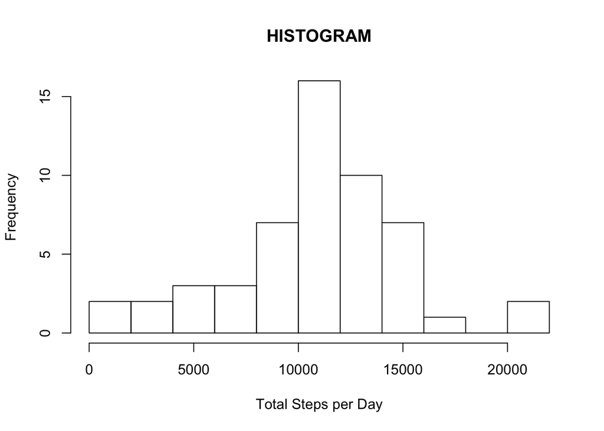

The mean of total steps per day for this distribution is:

```r
mean(histInput$x)
```

```
## [1] 10766
```

And the median of total steps per day for this distribution is:

```r
median(histInput$x)
```

```
## [1] 10765
```

### Average Daily Activity Pattern

Here’s a timeplot

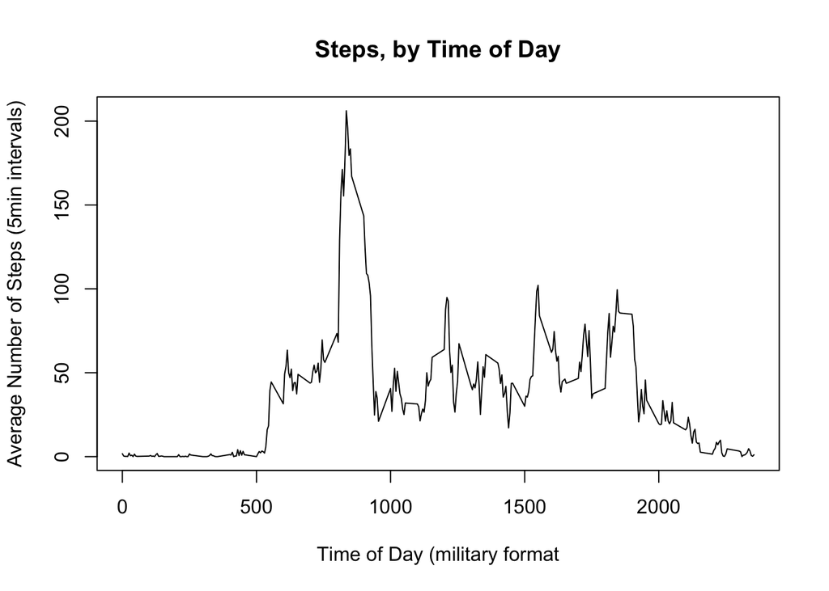

The interval with the greatest number of steps occurs at 835 and contains:

```r
max(timeplotInput$x)
```

```
## [1] 206.2
```

### Backfilling the Missing Values

The number of missing values in the dataset is:

```r
dim(rawActivity[!complete.cases(rawActivity),])[1]
```

```
## [1] 2304
```

I can “backfill” the missing data by filling in the missing value for each time-of-day interval with the rounded average for that interval for all of the days for which we do have data, as follows:

```r
missingActivity <- rawActivity[!complete.cases(rawActivity),]
```

```r
timeplotInput <- cbind(timeplotInput, xr = round(timeplotInput$x))
```

```r
missingActivity$steps <- timeplotInput$xr
```

```r
imputedActivity <- rbind(completeActivity, missingActivity)
```

Here’s a histogram showing the distribution of steps-per-day, for each of the 61 days where step data is available *or imputed.* I did **not** impute data for two dates: 10/2 and 11/15 where the steps-per-day were only 126 and 41 respectively. Perhaps I should have done so.

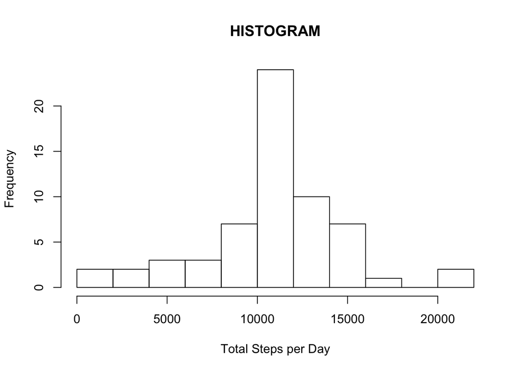

The mean of total steps per day for this distribution is:

```r
mean(hist2Input$x)
```

```
## [1] 10766
```

And the median of total steps per day for this distribution is:

```r
median(hist2Input$x)
```

```
## [1] 10762
```

Because of the method by which I imputed the missing data, the mean did not change, and the median changed only slightly.

### Weekdays vs Weekends

And finally, here’s a comparison of weekday vs weekend interval activity:

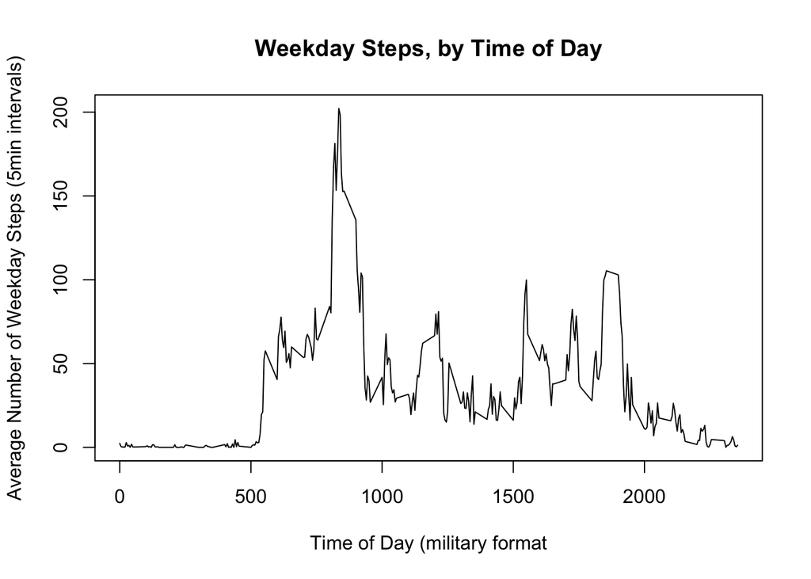

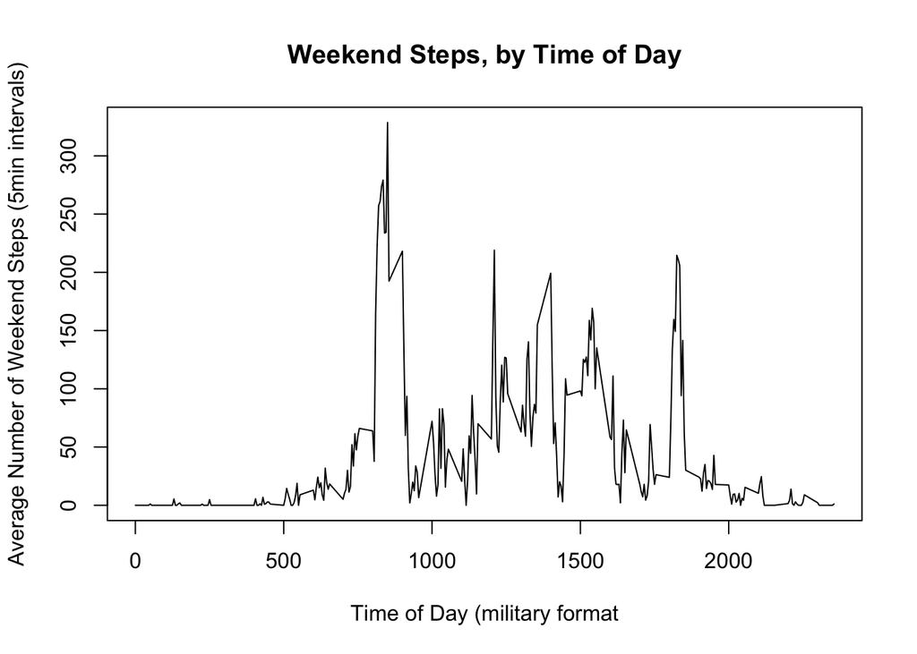